# Predicting Acute Kidney Injury in Mechanically Ventilated ICU Patients

A machine learning pipeline for early AKI detection using the MIMIC-IV critical care database

10,085ICU Stays

74Predictors

5ML Models

15.4%AKI Incidence

Overview Pipeline Cohort Demographics Model Performance Feature Importance Calibration Explorer Code & Data

## Overview

Clinical motivation and study design

Acute kidney injury (AKI) is a common and serious complication in mechanically ventilated ICU patients, associated with increased mortality, prolonged hospital stays, and long-term renal impairment. Early identification of patients at risk enables timely interventions including fluid management, nephrotoxin avoidance, and early renal consultation.

This project builds a complete predictive modeling pipeline using the [MIMIC-IV v3.1](https://physionet.org/content/mimiciv/3.1/) critical care database. The outcome of interest is **AKI Stage 2 or higher** (KDIGO criteria) within 7 days of mechanical ventilation initiation.

### Data Source

MIMIC-IV v3.1 — 330,000+ hospital admissions from Beth Israel Deaconess Medical Center (2008–2022)

### Outcome

AKI Stage 2+ within 7 days of intubation, defined by KDIGO creatinine criteria with imputed baseline

### Methods

Logistic regression, LASSO, random forest, XGBoost, and SVM with MICE imputation across 5 imputed datasets

## Analysis Pipeline

Reproducible, end-to-end workflow from raw EHR data to model interpretation

1

#### Cohort Construction

Identify mechanically ventilated patients (≥24h), apply clinical exclusion criteria (ESRD, elective surgery, pediatric), define AKI outcomes using KDIGO staging with CKD-EPI imputed baseline creatinine.

`01_cohort_construction.Rmd` R Clinical

2

#### Feature Engineering

Extract 74 candidate predictors from labs (28 categories), vitals, vasopressors, fluid balance, and ICD-coded comorbidities. Derive BMI, P/F ratio, SOFA components, and driving pressure.

`02_feature_engineering.Rmd` R

3

#### Multiple Imputation

Characterize missingness patterns across all features. Apply MICE (Multivariate Imputation by Chained Equations) to generate 5 complete datasets with principled uncertainty propagation.

`03_imputation.Rmd` Statistics

4

#### Machine Learning

Train and evaluate logistic regression, LASSO, random forest, XGBoost, and SVM using tidymodels. Pool predictions across all 5 imputed datasets following Rubin’s rules.

`04_machine_learning.Rmd` ML

5

#### Model Interpretation

`05_feature_analysis.Rmd` ML

## Cohort Construction

Systematic exclusion criteria following CONSORT guidelines

Starting from all ICU admissions with mechanical ventilation ≥24 hours, sequential exclusion criteria were applied to arrive at a clinically homogeneous cohort of 10,089 stays suitable for AKI prediction modeling.

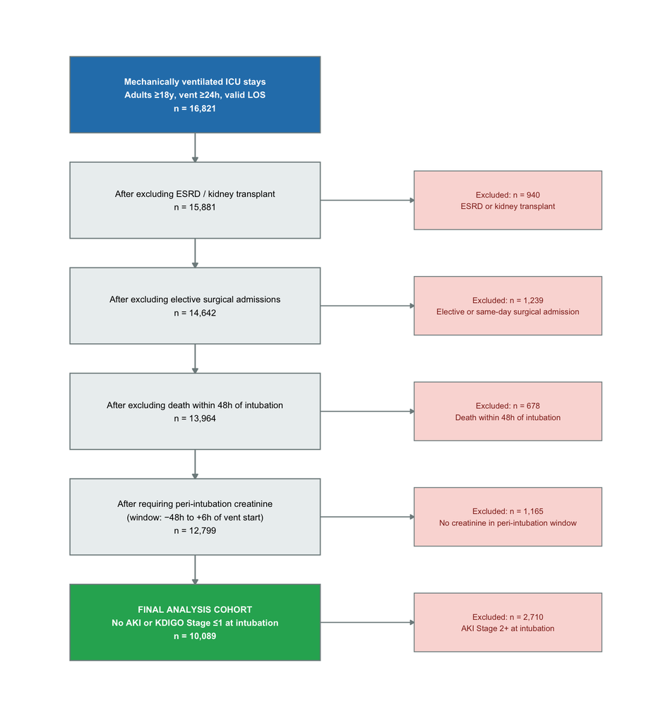

Figure 1. Sequential application of exclusion criteria to mechanically ventilated MIMIC-IV ICU stays yielded a final analysis cohort of 10,089 stays with no or mild AKI (KDIGO Stage ≤1) at intubation.

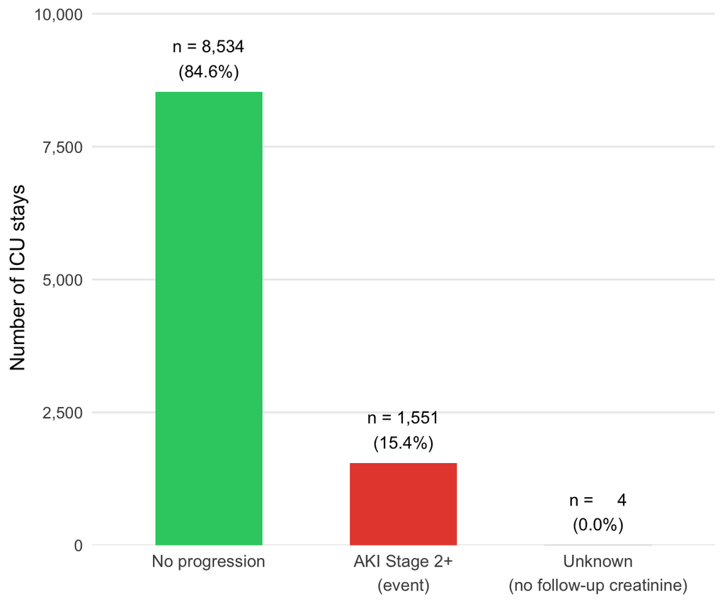

Figure 2. Distribution of the primary outcome across the final analysis cohort; AKI Stage 2+ within 7 days of intubation occurred in 15.4% of evaluable stays (1,551 of 10,085).

## Cohort Demographics

Patient characteristics stratified by 7-day AKI outcome (post-MICE, Imputation 1)

Table 1. Selected Cohort Characteristics by AKI Status

| Characteristic | Overall (N=10,085) | No AKI Progression (n=8,534) | AKI Stage 2+ (n=1,551) | p-value |
| --- | --- | --- | --- | --- |
| Age, years (median [IQR]) | 65.0 [53.0, 75.0] | 64.0 [53.0, 75.0] | 67.0 [56.0, 77.0] | <0.001 |
| Sex — Female | 4,175 (41.4%) | 3,542 (41.5%) | 633 (40.8%) | 0.630 |
| Sex — Male | 5,910 (58.6%) | 4,992 (58.5%) | 918 (59.2%) |  |

Full demographics table (57 characteristics) available in the [complete analysis report](https://github.com/ricapitogo-prog/aki-ards-prediction).

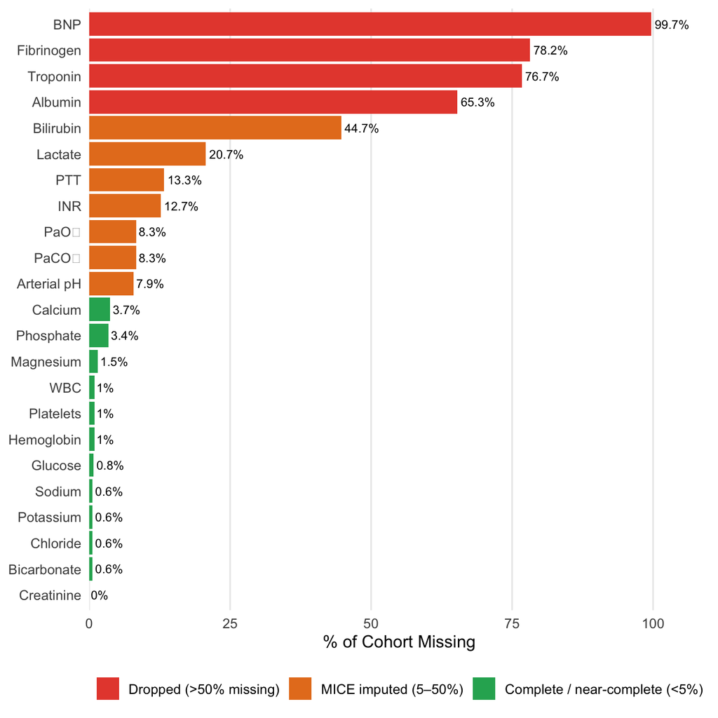

Figure 3. Laboratory variable missingness in the 24h post-intubation prediction window; variables exceeding 50% missingness (BNP, fibrinogen, troponin, albumin) were dropped prior to MICE imputation.

## Model Performance

Comparing five ML approaches with pooled predictions across 5 MICE imputations

Table 2. Discriminative Performance on Held-Out Test Set

| Model | AUROC | AUPRC |
| --- | --- | --- |
| Logistic Regression | 0.8009 | 0.4434 |
| XGBoost | 0.8003 | 0.4363 |
| LASSO | 0.8000 | 0.4434 |
| Random Forest | 0.7923 | 0.4282 |
| SVM | 0.7855 | 0.4195 |

Pooled predictions across 5 MICE imputations. Models ordered by descending AUROC.

Table 3. Classification Thresholds (Youden’s J)

| Model | Threshold | Sensitivity | Specificity | Youden’s J |
| --- | --- | --- | --- | --- |
| Logistic Regression | 0.1600 | 71.4% | 75.3% | 0.4666 |
| XGBoost | 0.1300 | 78.5% | 69.4% | 0.4782 |
| LASSO | 0.1700 | 68.8% | 77.4% | 0.4626 |
| Random Forest | 0.1700 | 74.3% | 70.9% | 0.4522 |
| SVM | 0.0500 | 100.0% | 0.0% | 0.0000 |

Thresholds derived by maximizing Youden’s J = sensitivity + specificity − 1 on held-out test set.

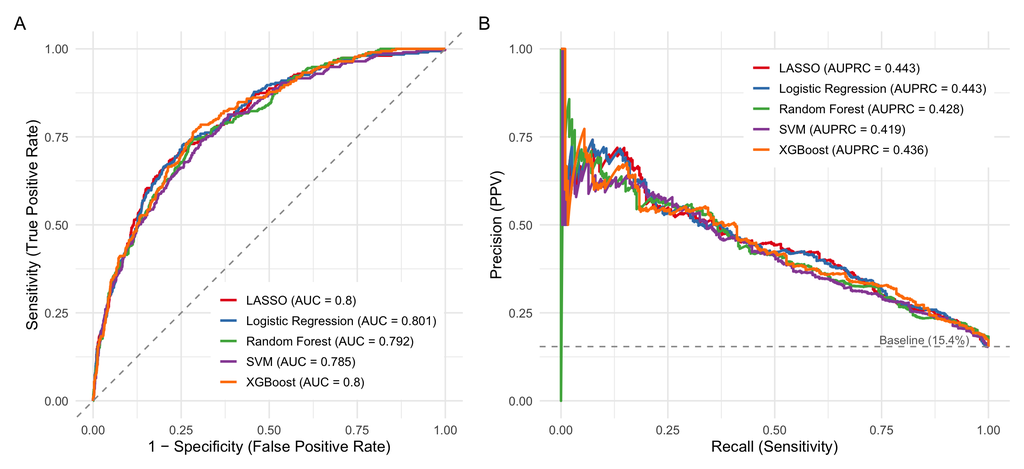

Figure 4. ROC curves (A) and precision-recall curves (B) for all five models on the held-out test set; pooled predictions across 5 MICE imputations.

## Feature Importance

SHAP-based interpretation of the XGBoost model

SHAP (SHapley Additive exPlanations) values provide both global feature rankings and patient-level explanations for each prediction. This helps clinicians understand which variables drive AKI risk predictions and build trust in model outputs.

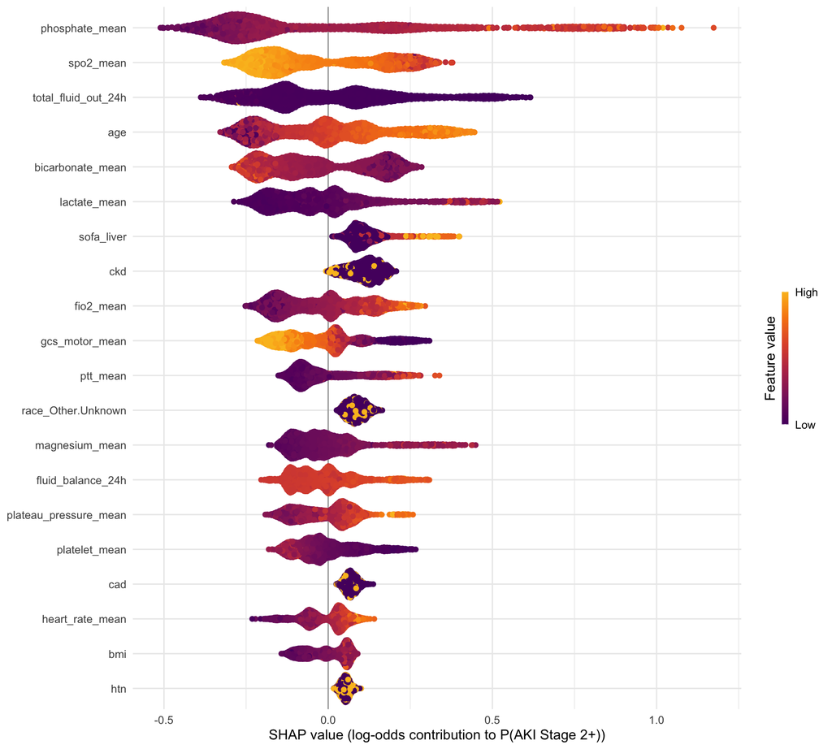

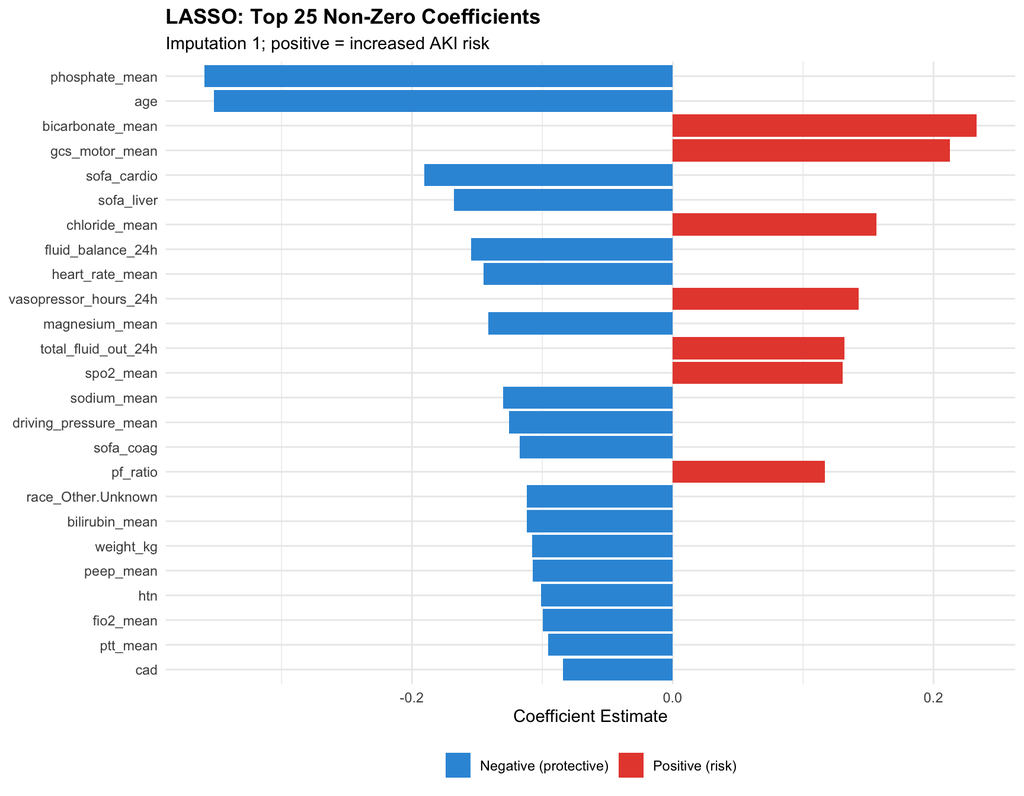

Figure 6. LASSO top 25 non-zero coefficients (imputation 1); red = features associated with increased AKI risk, blue = protective features.

## Model Calibration

Assessing reliability of predicted probabilities

Table 4. Brier Scores

| Model | Brier Score |
| --- | --- |
| Logistic Regression | 0.1070 |
| LASSO | 0.1071 |
| XGBoost | 0.1075 |
| Random Forest | 0.1088 |
| SVM | 0.1304 |

Brier score = mean(predicted_prob − observed_outcome)². Lower is better. Pooled across 5 MICE imputations.

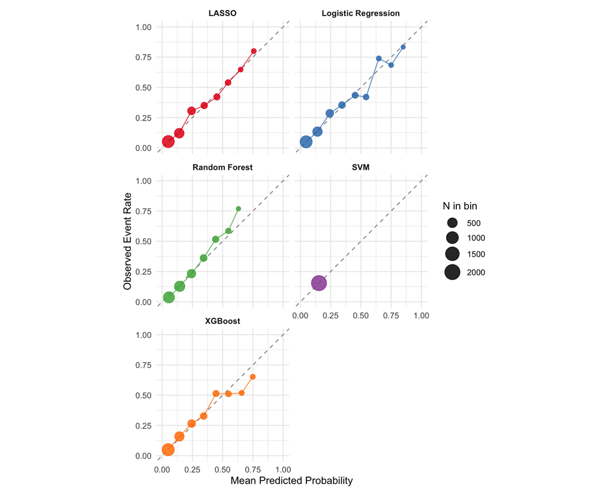

Figure 7. Calibration plots for all five models; each point represents a probability bin (sized by N), and the dashed diagonal represents perfect calibration.

## Code & Data

Fully reproducible pipeline

### Source Code

Full analysis pipeline available on [GitHub](https://github.com/ricapitogo-prog/aki-ards-prediction). All scripts are documented R Markdown files that can be rendered with knitr.

### Data Access

This project uses [MIMIC-IV v3.1](https://physionet.org/content/mimiciv/3.1/). Access requires PhysioNet credentialing and a signed data use agreement. No patient data is included in this repository.

### Interactive Dashboard

**Launch the Cohort Explorer** — filter by AKI stage, gender, race, and age to explore demographics, labs, and vitals interactively. No installation required. A full Shiny app is also available in `shiny_app/` for local use.

**Requirements:** R ≥ 4.5 • Key packages: `tidyverse`, `tidymodels`, `xgboost`, `mice`, `shapviz`, `teal`, `shiny`

**Rica Mae Pitogo** • UCLA Biostatistics

[GitHub](https://github.com/ricapitogo-prog)

Built with MIMIC-IV v3.1 • No patient data included in this repository